# Lesson 20

Timothy Luna

9/15/2019

# 3C-L2 Intrinsic Camera Parameters

## Intro

There are two parts to geometric camera calibration: *extrinsic* maps from world to camera coordinates and was expressed in terms of homogeneous coordinates, *intrinsic* maps from 3D camera coordinates to the 2D image plane via projection.

## Ideal vs Real Intrinsic Parameters

We’ve done ideal perspective projection where $u = f\frac{x}{z}$ and $v$ was $f\frac{y}{z}$. $f$ might be in mm, but pixels are an arbitrary coordinate! First we introduce an $\alpha$ to use as a scaling parameter, where some people might give you an $f$ which is $f$ combined with $\alpha$.

Pixels are not ideal squares and thus both x and y coordinates in the image plane need scaling parameters.

$u=\alpha\frac{x}{z}$ and $v = \beta\frac{y}{z}$

The center of projection was right at the camera coordinate system with the origin in the middle. The image may have been cropped, or the sensor might not be lined up with the optics. Now we have two offsets, one for the u direction and one for the v.

We’ve also assumed that $u$ and $v$ are orthogonal and normal to each other, but in reality the sensor may produce two non-ideal and non-perpindicular axes.

$v' \sin\theta = v$

$u' = u-\cos\theta v' = u-\cot\theta$

Combining all of this gives the intrinsic parameter representation

$u=\alpha\frac{x}{z}-\alpha\cot{\theta}\frac{y}{z} + u_0$

$v=\frac{\beta}{\sin\theta}\frac{y}{z}+v_0$

There are now five degrees of freedom.

## Improving Intrinsic Parameters

Let’s make this prettier. We’ve been dividing by $z$ and we can move to homogeneous coordinates.

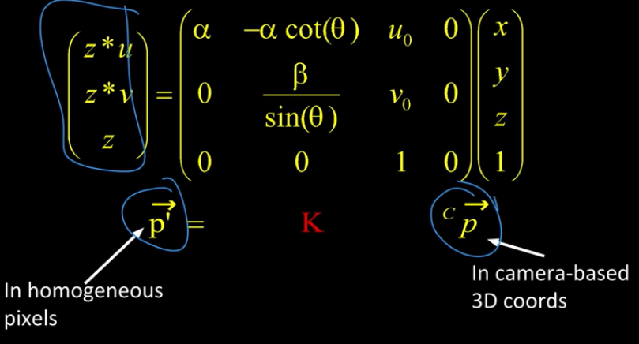

We can remove the last column and clean up some of the notation.

Think of the focal length as the overall focal length and if there’s a nonuniform width/height relationship we account for that with the aspect ratio.

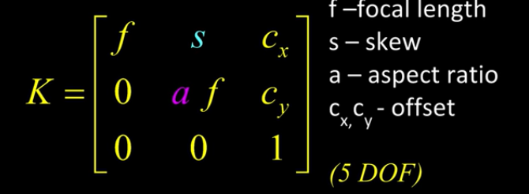

If we assume square pixels wth no skew and the optical center is in the middle then there’s only one degree of freedom, $f$.

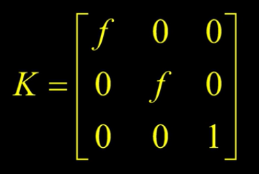

## Quiz: Intrinsics

How did we go from six to five? What happened? When we go from a 3d to a 2d projection the z degree of freedom becomes bound into the relationship between the remaining degrees of freedom.

## Combining Extrinsic and Intrinsic

We can combine the extrinsic and intrinsic matrices to go from world to camera.

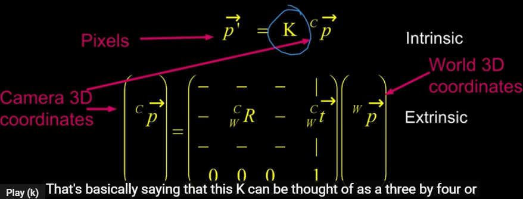

Remember that we drop the last column of $K$. $K$ can be thought of as a three by four or three by three.

The whole thing can be written as M

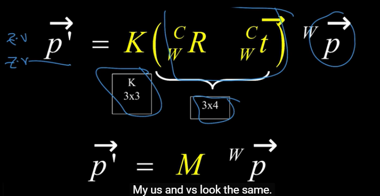

## Other Ways to Write the Same Equation

WHen we use $M$ we can write it in another way that makes it useful converting from world coordinates to pixel coordinates.

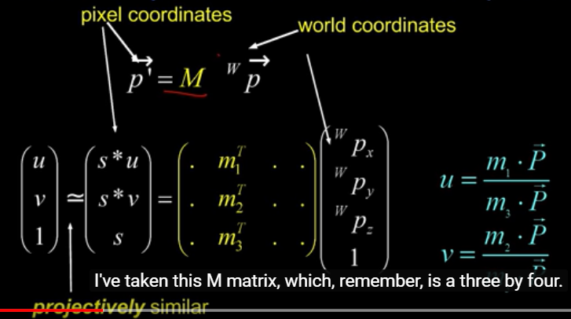

Previously the $M$ matrix was a three by four

$s$ is also a scaling operation. The ‘squiggly equals’ means projectively similar.

Now we have to find the elements of $M$!

## Camera Parameters

Now we can talk about camera parameters. A camera and it’s matrix $M$ (or $\Pi$) is described by a number of parameters.

- Translation $(T)$ of the optical center from the origin of world coordinates
- Rotation $(R)$ of the camera system
- Focal length $(f)$ and aspect $(a)$ (or pixel size $(s_w,s_v)$), principle point $(x' _ c,y' _ c)$, and skew $(s)$.

T and R are extrinsic parameters and the remainders are intrinsic parameters.

M is going to be built from all the effects of our parameters.

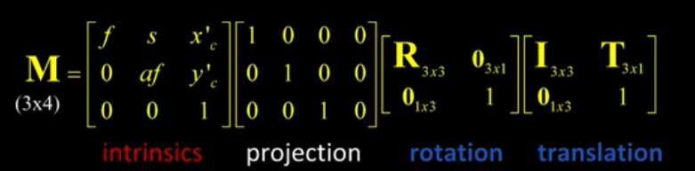

## End

Now we can map from a world coordinate down to the image plane using the translational matrices and calibration matrix. How do we *find* the calibration matrix? Coming up next!